# Comparison of candidate genes with other data sets

This document details the comparison of candidates identified as regulated by YB1 to other data sets I have on hand, such as survival and PARCLIP.

## Setting up the environment

These are packages you will need for this notebook. For exact versions used, please refer to the session info at the bottom of this notebook.

I want to set a base directory that we can use as a link to the directory where we will do most of the work. I use two directories here because the Workspace is what is pushed to GitHub and contains scripts and plot files, but the Repository is where more of the big data is stored that does not get pushed.

```r
generalDatasets = 'C:/Users/chris/OneDrive/Documents/bccrc/projectsRepository/generalDatasets'
baseWorkspace = 'C:/Users/chris/OneDrive/Documents/bccrc/projectsWorkspace/sorensenLab/relatedToYbx1'
baseRepository = 'C:/Users/chris/OneDrive/Documents/bccrc/projectsRepository/sorensenLab/relatedToYbx1'
```

We need to call a source file that has some functions we will need. For simplicity and ease of tracking, I make a copy of this file in each directory that I will work in in order to be able to trace the exact one functions that are used, in case I change them and mistakenly don’t push it to GitHub.

```r
source(paste(baseWorkspace, '/proteomics20200705_mg633CrisprYbx1GucClones/userDefinedFunctions.R', sep = ''))
```

## Data processing

First I need to read in the processed differential expression data.

```r
##########################################################################################
pro = read_csv(paste(baseRepository, '/proteomics20200705_mg633CrisprYbx1GucClones/dataset_deqmsGuc6-Parent.csv', sep = ''))
```

As a first set, we will look at things that are downregulated when YBX1 is also down.

```r
##########################################################################################
dnSet = pro %>%
  filter(sca.adj.pval <= 0.001 & logFC <= -1 & count > 1)
#there are 33 genes in this set
```

Now run these against our surival data.

```r
##########################################################################################
postelExpression = readRDS(paste(baseRepository, '/microarray20200604_ewingSarcomaAllSets/dataset_postelVinayExpression.rds', sep = ''))
postelPhenotype = readRDS(paste(baseRepository, '/microarray20200604_ewingSarcomaAllSets/dataset_postelVinayPhenotype.rds', sep = ''))
expressionData = postelExpression
phenotypeData = postelPhenotype
geneOfInterest = as.list(dnSet$gene)
coxZScores = lapply(geneOfInterest, survivalAnalysisV2,
                    expressionData = expressionData,
                    phenotypeData = phenotypeData,
                    survivalPlot = FALSE,
                    survivalData = FALSE,
                    writeDirectory = '/proteomics20200705_mg633CrisprYbx1GucClones',
                    printData = FALSE)
```

```
[1] "Performing analysis for PLOD2"
[1] "Performing analysis for LDHB"
[1] "Performing analysis for PSPC1"
[1] "Performing analysis for CDH2"
[1] "Performing analysis for SLFN11"
[1] "Performing analysis for SH3KBP1"
[1] "Performing analysis for STK26"
[1] "Performing analysis for SERPINB5"
[1] "Performing analysis for LAMC1"
[1] "Performing analysis for NAP1L1"
[1] "Performing analysis for NCAM1"
[1] "Performing analysis for APRT"
[1] "Performing analysis for TPD52"
[1] "Performing analysis for LAMA5"
[1] "Performing analysis for UBE2S"
```

[output cut: 18 more lines]

```r
dnSet$coxz = -log10(unlist(coxZScores))
```

```
NaNs produced
```

Now we can make a plot for these scores.

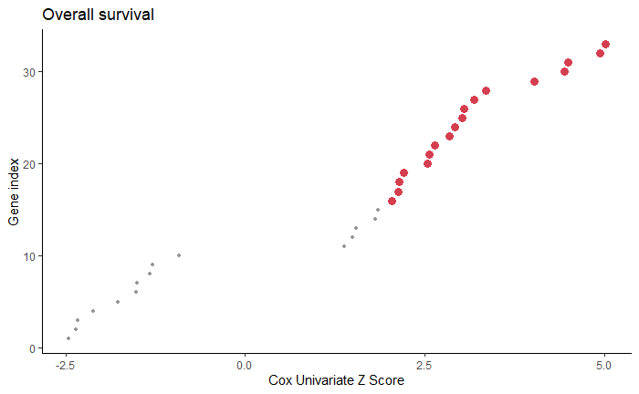

```r
##########################################################################################
dnSetPlot = dnSet %>%
  arrange(coxz) %>%
  mutate(index = seq(1,nrow(dnSet),1))
dnSetPlot$pText = ifelse(dnSetPlot$coxz >= 2, dnSetPlot$gene, '')
dnSetPlot$pSize = ifelse(dnSetPlot$coxz >= 2, 3, 1)
dnSetPlot$pColors = ifelse(dnSetPlot$coxz >= 2, brewer.pal(8,'Spectral')[1], brewer.pal(8,'Greys')[5])
#esHitsPlot$pText = ifelse(esHitsPlot$coxz >= 2.5, esHitsPlot$symbol, '')
##
ggplot(dnSetPlot, aes(coxz, index)) +
  geom_point(size = dnSetPlot$pSize, color = dnSetPlot$pColors) +
  geom_text_repel(label = dnSetPlot$pText, size = 2, segment.size = 0.2, nudge_x = -1) +
  labs(x = 'Cox Univariate Z Score', y = 'Gene index', title = 'Overall survival') +
  theme_classic()
ggsave(paste(baseRepository, '/proteomics20200705_mg633CrisprYbx1GucClones/scatter_postelVinayOvsYbx1Guc6Down.pdf', sep = ''),
       width = 3, height = 4, useDingbats = FALSE)
```

Plot some candidates from the Chen PARCLIP data we processed previously.

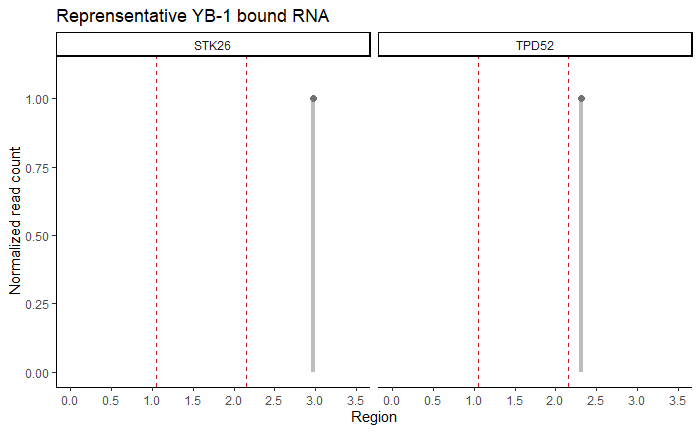

```r
##########################################################################################
parclip = readRDS(paste(baseRepository, '/sequencing20200527_ybx1ParclipChen/dataset_yb1ParclipAnnotatedPeakSet.rds', sep = ''))
##genes of interest
goi = c('STK26','TPD52')
parclipSub = parclip[parclip$txdbSymbol %in% goi,]
parclipSub$txdbSymbol = factor(parclipSub$txdbSymbol, levels =c('STK26','TPD52'))
##normalize the values so that they are relative to the max peak
parclipNorm = tibble()
for (i in 1:length(goi)){
  gnSubset = parclipSub[parclipSub$txdbSymbol == goi[i],]
  gnSubset$normPeak = gnSubset$readCountSum / max(gnSubset$readCountSum, na.rm = TRUE)
  parclipNorm = rbind(parclipNorm, gnSubset)
}

##make a plot
ggplot(parclipNorm, aes(regionLocationAdjusted, normPeak)) +
  geom_segment(aes(x = regionLocationAdjusted, y = 0, xend = regionLocationAdjusted, yend = normPeak), color = brewer.pal(9,'Greys')[4], size = 1.5) +
  geom_point(size = 2, color = brewer.pal(9,'Greys')[6]) +
  geom_vline(xintercept = c(1.05,2.15), linetype = 'dashed', color = brewer.pal(9,'Reds')[7]) +
  scale_y_continuous(limits = c(0,1.1), breaks = seq(0,2,0.25)) +
  scale_x_continuous(limits = c(0,3.5), breaks = seq(0,3.5,0.5)) +
  labs(x = 'Region', y = 'Normalized read count', title = 'Reprensentative YB-1 bound RNA') +
  theme_classic() +
  theme(legend.position = 'none') +
  facet_wrap(~txdbSymbol, nrow = 1)
##write plot to a file
ggsave(paste(baseRepository, '/proteomics20200705_mg633CrisprYbx1GucClones/lollipop_candidateBoundRNAs.pdf', sep = ''),
       useDingbats = FALSE,
       width = 3,
       height = 4)
```

[session information not shown]